# K-means Clustering

[figure not shown]

## Contenidos

1. Introduccion  
   1.1.Que es K-means  
   1.2.Aplicaciones
1. TEORÍA
1. ¿Como funciona?  
   3.1 Paso 1 : Elección del valor de K  
   3.2 El método del codo (Elbow Method)
2. Importar librerias 📚  
   4.1 Numpy  
   4.2 Pandas  
   4.3 Matplotlib  
   4.4 Seaborn
1. Datos  
   5.1 Análisis de datos exploratorios  
   5.2 Variable(s) categórica en numeros
1. Normalización estadística
1. método del codo
1. K-Means con diferentes clústeres
1. Plot

## 1.- Introduccion 🃏

### 1.1- Que es K-means 🧐

- El agrupamiento "K-means" es un método de cuantificación de vectores, originalmente a partir del procesamiento de señales, que tiene como objetivo dividir n observaciones en k grupos en los que cada observación pertenece al grupo con la media más cercana (centros de grupo o centroide de grupo), sirviendo como un prototipo de el racimo. Esto da como resultado una partición del espacio de datos en celdas de Voronoi. El agrupamiento de k-medias minimiza las varianzas dentro del grupo (distancias euclidianas cuadradas), pero no distancias euclidianas regulares, que sería el problema de Weber más difícil: la media optimiza los errores cuadrados, mientras que solo la mediana geométrica minimiza las distancias euclidianas. Por ejemplo, se pueden encontrar mejores soluciones euclidianas usando K-mean y k-medoids. El algoritmo K-Means funciona de forma iterativa para asignar cada punto de datos a uno de los K grupos según las características que se proporcionan. Los puntos de datos se agrupan según la similitud de características.

Para saber mas ver: [K-means](https://en.wikipedia.org/wiki/K-means_clustering)

### 1.2.- Aplicaciones 🔨

K-means es bastante fácil de aplicar incluso a grandes conjuntos de datos. Se ha utilizado con éxito en la segmentaciónes de mercado, visión por computadora y astronomía, entre muchos otros. A menudo se utiliza como paso de "preprocesamiento" para otros algoritmos, por ejemplo, para encontrar una configuración inicial. Algunos usos son por ejemplo:

- Cuantización vectorial
- Análisis de conglomerados
- Aprendizaje de funciones

Para saber mas ver: [K-means Aplicaciones](https://en.wikipedia.org/wiki/K-means_clustering#Applications)

## 2.- TEORÍA 🤓

Go to Top

La agrupación en clústeres de K-means es una solucion dacil para particionar un conjunto(s) de datos en K grupos distintos. Para realizar un K-means, primero debemos especificar el número de grupos K, entonces la el algoritmo asignará a cada dato a una K agrupacionen.

La agrupación de K-medias se puede representar en forma de diagrama de la siguiente manera:

[figure not shown]

K-means agrupa los datos tratando de separar muestras en N grupos de igual varianza, minimizando un criterio conocido como inercia o suma de cuadrados dentro del grupo. El algoritmo de K-means tiene como objetivo elegir un centroide que minimice la inercia, o el criterio de suma de cuadrados dentro del clúster.

$$ \sum_{i=0}^n \min_ {μ_j ϵC} ‖x_i-μ_j ‖^2 $$

## 3.- ¿Como funciona? 🤔

Go to Top

### 3.1.- Paso 1 : Elección del valor de K 💡

K-Means depende de encontrar un número de grupos y etiquetas de datos para un valor predefinido de K.Para encontrar el número de grupos en los datos, necesitamos ejecutar el algoritmo de agrupamiento de K-Means para diferentes valores de K y comparar los resultados. Por tanto, el rendimiento del algoritmo K-Means depende del valor de K. Debemos elegir el valor óptimo de K que nos dé el mejor rendimiento. Hay diferentes técnicas disponibles para encontrar el valor óptimo de K. La técnica más común es el método del codo.

### 3.2.- El método del codo (Elbow Method) 📉

Este método utiliza los valores de la inercia obtenidos tras aplicar el K-means a diferente número de Clusters (desde 1 a N Clusters), siendo la inercia la suma de las distancias al cuadrado de cada objeto del Cluster a su centroide:

$$inercia = \sum_{i=0}^n \min_ {μ_j ϵC} ‖x_i-μ_j ‖^2 $$

Una vez obtenidos los valores de la inercia tras aplicar el K-means de 1 a N Clusters, representamos en una gráfica lineal la inercia respecto del número de Clusters. En esta gráfica se debería de apreciar un cambio brusco en la evolución de la inercia, teniendo la línea representada una forma similar a la de un brazo y su codo. El punto en el que se observa ese cambio brusco en la inercia nos dirá el número óptimo de Clusters a seleccionar para ese data set; o dicho de otra manera: el punto que representaría al codo del brazo será el número óptimo de Clusters para ese data set.

[figure not shown]

Es posible que al aplicar este método para ciertos conjunto de datos no se aprecie “el codo” o incluso se observen dos o más codos (o cambios bruscos en la evolución de la inercia). En ese caso habría que estudiar más en detalle o con otras técnicas el número optimo de Clusters a seleccionar. Dada la finalidad didáctica de estos ejemplos, se aprecia muy bien “el codo” en la evolución de la inercia, pero en la realidad no siempre se observa este comportamiento tan claro.

## 4.- Importar librerias 📚

Go to Top

```python
import numpy as np
import pandas as pd

import matplotlib.pyplot as plt
import seaborn as sns

%matplotlib inline
```

### 4.1.- numpy 📗

**Instalación**

> `conda install -c anaconda -y numpy`

**Descripción**

Numpy es una biblioteca para el lenguaje de programación Python que (entre otras cosas) brinda soporte para grandes matrices multidimensionales.

¿Por qué es eso importante? Usando NumPy, podemos expresar imágenes como matrices multidimensionales.

Representar imágenes como matrices NumPy no solo es computacional y eficiente en el uso de recursos, sino que muchas otras bibliotecas de procesamiento de imágenes y aprendizaje automático también usan representaciones de matrices NumPy. Además, al usar las funciones matemáticas de alto nivel incorporadas de NumPy, podemos realizar rápidamente análisis numéricos en una imagen.

**Link**

[Numpy](https://numpy.org/)

### 4.2.- pandas 📘

**Instalación**

> `pip install pandas`

o

> `conda install -c anaconda pandas`

**Descripción**

pandas es una herramienta de manipulación y análisis de datos de código abierto rápida, potente, flexible y fácil de usar, construido sobre el lenguaje de programación Python.

**Link**

[pandas](https://pandas.pydata.org/)

### 4.3.- Matplotlib 📕

**Instalación**

> `conda install -c conda-forge -y matplotlib`

**Descripción**

Matplotlib es una biblioteca para la generación de gráficos a partir de datos contenidos en listas o arreglos en el lenguaje de programación Python y su extensión matemática NumPy.

Por medio del comando mágico **%matplotlib inline** se indica que los despliegues gráficos de la biblioteca matplotlib se despliegan en el cuaderno Jupyter directamente.

**Link**

[Matplotlib](https://matplotlib.org/)

### 4.4.- Seaborn 📒

**Instalación**

> `pip install seaborn`

o

> `conda install -c anaconda seaborn`

**Descripción**

Seaborn es una biblioteca de visualización de datos de Python basada en matplotlib. Proporciona una interfaz de alto nivel para dibujar gráficos estadísticos atractivos e informativos.

**Link**

[seaborn](https://seaborn.pydata.org/)

## 5.- Datos 🗄️

Go to Top

```python
path_data = "./Data/Mall_Customers.csv"

df = pd.read_csv(path_data)
```

### 5.1.- Análisis de datos exploratorios

**`Ver lo largo y anho de los datos`**

```python
df.shape
```

```
(200, 5)
```

**`Ver un resumen conciso del DataFrame.Ver resumen del conjunto de datos`**

```python
df.info()
```

```
<class 'pandas.core.frame.DataFrame'>
RangeIndex: 200 entries, 0 to 199
Data columns (total 5 columns):
 #   Column                  Non-Null Count  Dtype
---  ------                  --------------  -----
 0   CustomerID              200 non-null    int64
 1   Gender                  200 non-null    object
 2   Age                     200 non-null    int64
 3   Annual Income (k$)      200 non-null    int64
 4   Spending Score (1-100)  200 non-null    int64
dtypes: int64(4), object(1)
memory usage: 7.9+ KB
```

**`Detecta valores perdidos.`**

```python
df.isnull().sum()
```

```
CustomerID                0
Gender                    0
Age                       0
Annual Income (k$)        0
Spending Score (1-100)    0
dtype: int64
```

**`Imprime las primeras filas.`**

```python
df.head()
```

|  | CustomerID | Gender | Age | Annual Income (k$) | Spending Score (1-100) |
| --- | --- | --- | --- | --- | --- |
| 0 | 1 | Male | 19 | 15 | 39 |
| 1 | 2 | Male | 21 | 15 | 81 |
| 2 | 3 | Female | 20 | 16 | 6 |
| 3 | 4 | Female | 23 | 16 | 77 |
| 4 | 5 | Female | 31 | 17 | 40 |

**`Genera estadísticas descriptivas.`**

```python
df.describe()
```

|  | CustomerID | Age | Annual Income (k$) | Spending Score (1-100) |
| --- | --- | --- | --- | --- |
| count | 200.000000 | 200.000000 | 200.000000 | 200.000000 |
| mean | 100.500000 | 38.850000 | 60.560000 | 50.200000 |
| std | 57.879185 | 13.969007 | 26.264721 | 25.823522 |
| min | 1.000000 | 18.000000 | 15.000000 | 1.000000 |
| 25% | 50.750000 | 28.750000 | 41.500000 | 34.750000 |
| 50% | 100.500000 | 36.000000 | 61.500000 | 50.000000 |
| 75% | 150.250000 | 49.000000 | 78.000000 | 73.000000 |
| max | 200.000000 | 70.000000 | 137.000000 | 99.000000 |

Evaluar la importancia de las variables categóricas y ID

```python
df['CustomerID'].unique()
```

[output not shown]

```python
len(df['CustomerID'].unique())
```

```
200
```

Contamos con 200 etiquetas de identificación únicas para la variable **`CustomerID`** en un conjunto de datos de 200 registros, esto quiere decir que existe un identificador único para cada uno de los registros, por lo tanto no es una variable que otorgue valor valor y la borraremos

```python
df['Gender'].unique()
```

```
array(['Male', 'Female'], dtype=object)
```

```python
len(df['Gender'].unique())
```

```
2
```

Contamos con 2 categorías de etiquetas en la variable **`Gender`**.

Borramos **`CustomerID`** del Data Frame

```python
df.drop(['CustomerID'], axis=1, inplace=True)
```

Repetimos el análisis para saber que tenemos

```python
df.info()
```

```
<class 'pandas.core.frame.DataFrame'>
RangeIndex: 200 entries, 0 to 199
Data columns (total 4 columns):
 #   Column                  Non-Null Count  Dtype
---  ------                  --------------  -----
 0   Gender                  200 non-null    object
 1   Age                     200 non-null    int64
 2   Annual Income (k$)      200 non-null    int64
 3   Spending Score (1-100)  200 non-null    int64
dtypes: int64(3), object(1)
memory usage: 6.4+ KB
```

```python
df.head()
```

|  | Gender | Age | Annual Income (k$) | Spending Score (1-100) |
| --- | --- | --- | --- | --- |
| 0 | Male | 19 | 15 | 39 |
| 1 | Male | 21 | 15 | 81 |
| 2 | Female | 20 | 16 | 6 |
| 3 | Female | 23 | 16 | 77 |
| 4 | Female | 31 | 17 | 40 |

```python
df.describe()
```

|  | Age | Annual Income (k$) | Spending Score (1-100) |
| --- | --- | --- | --- |
| count | 200.000000 | 200.000000 | 200.000000 |
| mean | 38.850000 | 60.560000 | 50.200000 |
| std | 13.969007 | 26.264721 | 25.823522 |
| min | 18.000000 | 15.000000 | 1.000000 |
| 25% | 28.750000 | 41.500000 | 34.750000 |
| 50% | 36.000000 | 61.500000 | 50.000000 |
| 75% | 49.000000 | 78.000000 | 73.000000 |
| max | 70.000000 | 137.000000 | 99.000000 |

Podemos ver que hay 1 columna no numérica **`Gender`** en el conjunto de datos. Lo convertiremos en equivalentes enteros.

### 5.2.- variable(s) categórica en numeros 🔢

Declarar df final

```python
X = df
```

Convertir variable categórica en numeros

```python
from sklearn.preprocessing import LabelEncoder

le = LabelEncoder()

X['Gender'] = le.fit_transform(X['Gender'])
```

AED Rapido

```python
X.info()
```

```
<class 'pandas.core.frame.DataFrame'>
RangeIndex: 200 entries, 0 to 199
Data columns (total 4 columns):
 #   Column                  Non-Null Count  Dtype
---  ------                  --------------  -----
 0   Gender                  200 non-null    int32
 1   Age                     200 non-null    int64
 2   Annual Income (k$)      200 non-null    int64
 3   Spending Score (1-100)  200 non-null    int64
dtypes: int32(1), int64(3)
memory usage: 5.6 KB
```

```python
X.head()
```

|  | Gender | Age | Annual Income (k$) | Spending Score (1-100) |
| --- | --- | --- | --- | --- |
| 0 | 1 | 19 | 15 | 39 |
| 1 | 1 | 21 | 15 | 81 |
| 2 | 0 | 20 | 16 | 6 |
| 3 | 0 | 23 | 16 | 77 |
| 4 | 0 | 31 | 17 | 40 |

## 6.- normalización estadística 📋

Go to Top

```python
cols = X.columns
```

```python
from sklearn.preprocessing import MinMaxScaler

ms = MinMaxScaler()

X = ms.fit_transform(X)
```

```python
X = pd.DataFrame(X, columns=[cols])
```

```python
X.head()
```

|  | Gender | Age | Annual Income (k$) | Spending Score (1-100) |
| --- | --- | --- | --- | --- |
| 0 | 1.0 | 0.019231 | 0.000000 | 0.387755 |
| 1 | 1.0 | 0.057692 | 0.000000 | 0.816327 |
| 2 | 0.0 | 0.038462 | 0.008197 | 0.051020 |
| 3 | 0.0 | 0.096154 | 0.008197 | 0.775510 |
| 4 | 0.0 | 0.250000 | 0.016393 | 0.397959 |

## 7.- Utilice el método del codo para encontrar el K-número óptimo para los datos 📉

Go to Top

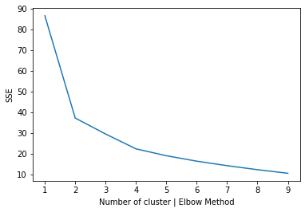

```python
from sklearn.cluster import KMeans

sse = {}

for k in range(1, 10):
    kmeans = KMeans(n_clusters=k, max_iter=1000)
    kmeans.fit(X)
    #print(data["clusters"])
    sse[k] = kmeans.inertia_ # Inertia: Sum of distances of samples to their closest cluster center

plt.figure()
plt.plot(list(sse.keys()), list(sse.values()))
plt.xlabel("Number of cluster | Elbow Method")
plt.ylabel("SSE")
plt.show()
```

## 8.- K-Means con diferentes clústeres 🧮

Go to Top

n_clusters = 2

```python
kmeans = KMeans(n_clusters=2, random_state=0)

kmeans.fit(X)

# check how many of the samples were correctly labeled
labels = kmeans.labels_
```

```python
kmeans.inertia_
```

```
37.27227241211877
```

```python
n_clusters = 3
```

```python
kmeans = KMeans(n_clusters=3, random_state=0)

kmeans.fit_predict(X)

# check how many of the samples were correctly labeled
labels = kmeans.labels_
```

```python
kmeans.inertia_
```

```
29.552857611943868
```

```python
n_clusters = 4
```

```python
kmeans = KMeans(n_clusters=4, random_state=0)

kmeans.fit_predict(X)

# check how many of the samples were correctly labeled
labels = kmeans.labels_
```

```python
kmeans.inertia_
```

```
22.39096001192855
```

```python
centers_on_PCs = kmeans.cluster_centers_
```

## 9.- Plot 🎨

Go to Top

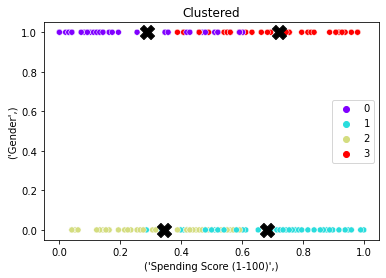

```python
### palette = sns.color_palette('bright', len(set(labels)))
sns.scatterplot(X.iloc[:,3], X.iloc[:, 0], hue=labels, legend='full', palette="rainbow")
plt.scatter(x=centers_on_PCs[:,3],y=centers_on_PCs[:,0],s=200,c="k",marker="X")
plt.title('Clustered')
```

## Si te sirvio, COMPARTE! 🤗

- Adios

## Mis redes:

- [GIT](https://github.com/sensito)
- [linkedin](https://www.linkedin.com/in/daniel-ivan-medina-barreras-b9725715a/)